# Predict antibiotic resistance w gene sequence

Kuzmichenko Polina 06-901

Achkasov Konstantin 06-906

Раннее выявление устойчивости возбудителей к противомикробным препаратам и назначение более эффективных антибиотиков является быстро растущей потребностью в клинической практике. Технология высокопроизводительного секвенирования, такая как секвенирование всего генома (WGS), может иметь возможность быстро направлять процесс принятия клинических решений.

В данной работе для задачи классификации использовались нейронные сети , а точнее сверточные нейронные сети.

Нейронная сеть — это универсальная модель, решающая широкий класс задач регрессии и классификации.

Пусть $${(x_i, y_i)}_{i=1}^l$$ — обучающая выборка в задаче регрессии, $$ x_i \in R^d $$ — признаковое описание i-го объекта выборки,$$ y_i \in R^1 $$ — значение целевой зависимой переменной на i-ом объекте выборки. Требуется построить поверхность a(x), аппроксимирующую неизвестную целевую зависимость.

В задачах классификации целевая переменная y принимает конечное множество значений и называется меткой класса.

Требуется построить разделяющую поверхность: $$ a(x) \rightarrow y \in \{0 ,1\} $$

Нейронная сеть считается универсальной моделью, так как она способна аппроксимировать любые поверхности. Соответствующую теорему сформулировал в 1957 году Андрей Николаевич Колмогоров.

### Структура сверточной нейронной сети

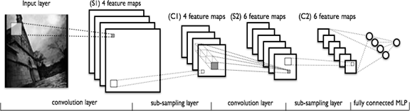

При обучении для каждого образца на вход свёрточной нейронной сети попадает не вся картинка 𝑚 × 𝑛, а только ее часть 𝑟 × c, 0, эта часть называется фильтром или ядром и она сдвигается по большой картинке.

При использовании свёрточной нейронной сети возникает проблема – большое количество выделенных признаков. Для одной большой картинки 𝑚 × 𝑛 будет (𝑚−𝑟+1)×(𝑛−𝑐+1) маленьких картинок 𝑟×𝑐, и количество выделенных признаков равно 𝑘 × (𝑚 − 𝑟 + 1) × (𝑛 − 𝑐 + 1) = 50 × (100 − 10 + 1) × (100 − 10 + 1) = 414 050. Использование такого огромного количества признаков для классификации оказалось неэффективно.Для уменьшения размера пространства признаков проводим субдискретизацию (англ. pooling), разделив карту признаков, полученных от свёрточной нейронной сети, на фиксированное количество частей 𝑝, см. рис. 3, на этом рисунке 𝑝 = 𝑝𝑚 × 𝑝𝑛 = 2 × 2 = 4 и на каждой части вычисляется ее максимальное значение (англ. max pooling) или среднее значение (англ. mean pooling).

Известно, что метод векторного представления слов широко используется для решения задачи классификации текстов. В этом методе каждое слово представляется как числовой вектор из $ R^n $.

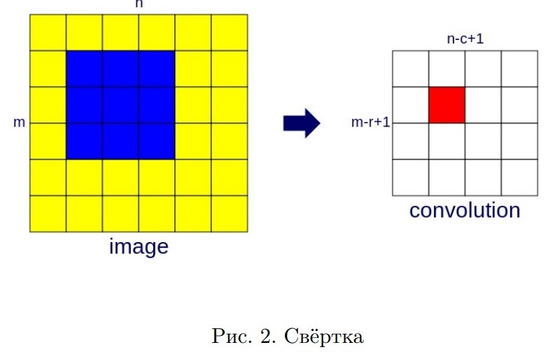

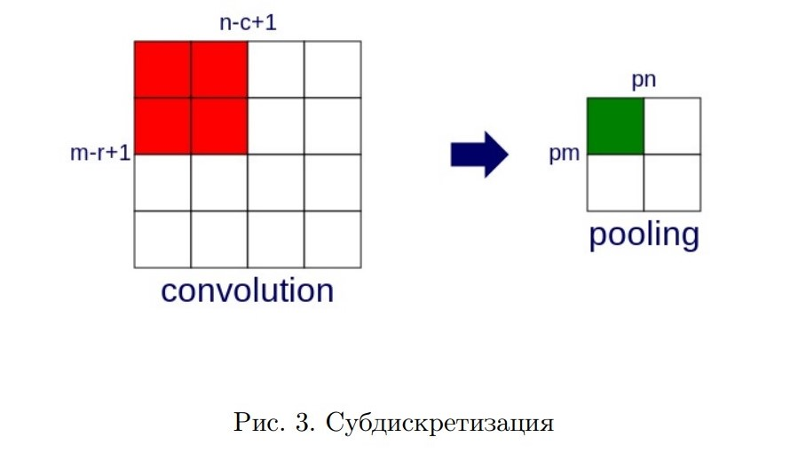

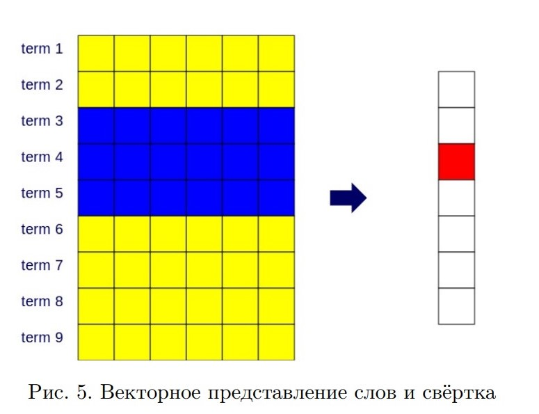

```python
display(Image('1.jpg',width=300))
display(Image('2.jpg',width=300))
display(Image('3.jpg',width=300))
```

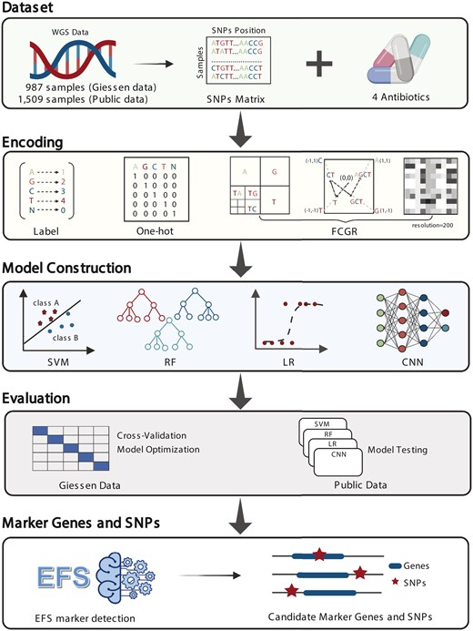

#### ЦЕЛИ

Особенности: Геномная последовательность, 4 буквы, порядок которых очень важен.

Метка: верно или неверно - устойчива ли она к антибиотику (или классу антибиотиков)

Геномная строка должна быть сначала токенизирована в четыре буквы G,C,T,A

Модели должны иметь возможность работать с текстовыми последовательностями, учитывая порядок

Поскольку набор данных хорошо сбалансирован 0.502 является ложным, а остальные - истинными - точность угадывания / проверка работоспособности = 50%

Представление модельных кодонов вместо нуклеотидов = 99%

```python
import os
import keras
import numpy as np
import pandas as pd
import matplotlib.pyplot as plt
%matplotlib inline

from keras.models import Sequential
from keras.layers import Flatten, Dense, Dropout, Embedding, LSTM
from keras import regularizers, layers, preprocessing
from sklearn.metrics import confusion_matrix, precision_score, recall_score, accuracy_score, f1_score
from sklearn.metrics import roc_auc_score, roc_curve, precision_recall_curve, average_precision_score


from keras.preprocessing.text import Tokenizer
from keras.preprocessing.sequence import pad_sequences


import tensorflow as tf
```

## Загрузка данных

```python
DataRaw = np.load('dataset.npy', allow_pickle=True)
print(type(DataRaw))
print(DataRaw.ndim)
DataRaw
```

```
<class 'numpy.ndarray'>
0
```

```
array({'resistant': array([False, False, False, ...,  True,  True, False]), 'genes': array(['ATGCACTACCGTATGATCCCCCTTCACTGGATGATGGAAATTGACTGCAATGGCTGCGCTAATAATACTTTGTCTCGTCGTTGGAATTACGACTTCTGGCACAAACACGTTGAACAGGTTAAATGCTACCGTCACAATATTCGTGACCAGACTTGA',
       'ATGCACTACCGTATGATTCACTGGATGATGGAAATTGACTGCAATGGCTGCGCTAATAATACTTTGTCTCGTCGTTGGAATTACGACTTCTGGCACAAACCCGTTGAACAGGTTAAATGCTACCGTCACAATATTCGTGACCAGACTTGA',
       'ATGCACTACCGTATGATTCACTGGATCGTGATGGAAATTGACTGCAATGGCTGCGCTAATAATACTTTGTCTCGTCGTTGGAATTACGACTTCTGGCACAAACACGTTGAACAGGTTAAATGCTACCGTCACAATATTCGTGACCAGACTTGA',
       ...,
       'ATGCACTACCGTATGATTCACTGGATGATGGAAACTGCAATGGCTGCGCTAATAATACTTTGTCTCGTCGTTGGAATTACGACTTCTGGCACAAACACGTTGAACAGGTTAAATGCTACCGTCACAATATTCGTGACCAGACTTGA',
       'ATGCACTACCGTATGATTCACTGGATGATGGAAATTGACTTGCAATGGCTGCGCTAATAATACTTTGTCTCGTCGTTGGAATTACGACTTCTGGCACAAACACGTTGAACAGGTTAAATGCTACCGTCACAATATTCGTGACCAGACTTGA',
       'ATGCACTACCGTATGATTCACTGGATGATGGAAATTGACTGCAATGGCTGCGCTAATAATACTTTGTCTCGTCGTTGGAATTACGACTTCTGGCACAAACACGTTGAACAGGTTAAATGCTACCGTCACAATATTCGTGACCAGACTTGA'],
      dtype=object)}, dtype=object)
```

Переконвертируем файл numpy в pandas

```python
# As a dictionary
Datadict = DataRaw[()]
print(Datadict)

# As a dataframe
DataDf = pd.DataFrame.from_dict(Datadict)
print(DataDf.shape)
DataDf
```

```
{'resistant': array([False, False, False, ...,  True,  True, False]), 'genes': array(['ATGCACTACCGTATGATCCCCCTTCACTGGATGATGGAAATTGACTGCAATGGCTGCGCTAATAATACTTTGTCTCGTCGTTGGAATTACGACTTCTGGCACAAACACGTTGAACAGGTTAAATGCTACCGTCACAATATTCGTGACCAGACTTGA',
       'ATGCACTACCGTATGATTCACTGGATGATGGAAATTGACTGCAATGGCTGCGCTAATAATACTTTGTCTCGTCGTTGGAATTACGACTTCTGGCACAAACCCGTTGAACAGGTTAAATGCTACCGTCACAATATTCGTGACCAGACTTGA',
       'ATGCACTACCGTATGATTCACTGGATCGTGATGGAAATTGACTGCAATGGCTGCGCTAATAATACTTTGTCTCGTCGTTGGAATTACGACTTCTGGCACAAACACGTTGAACAGGTTAAATGCTACCGTCACAATATTCGTGACCAGACTTGA',
       ...,
       'ATGCACTACCGTATGATTCACTGGATGATGGAAACTGCAATGGCTGCGCTAATAATACTTTGTCTCGTCGTTGGAATTACGACTTCTGGCACAAACACGTTGAACAGGTTAAATGCTACCGTCACAATATTCGTGACCAGACTTGA',
       'ATGCACTACCGTATGATTCACTGGATGATGGAAATTGACTTGCAATGGCTGCGCTAATAATACTTTGTCTCGTCGTTGGAATTACGACTTCTGGCACAAACACGTTGAACAGGTTAAATGCTACCGTCACAATATTCGTGACCAGACTTGA',
       'ATGCACTACCGTATGATTCACTGGATGATGGAAATTGACTGCAATGGCTGCGCTAATAATACTTTGTCTCGTCGTTGGAATTACGACTTCTGGCACAAACACGTTGAACAGGTTAAATGCTACCGTCACAATATTCGTGACCAGACTTGA'],
      dtype=object)}
(100000, 2)
```

|  | resistant | genes |
| --- | --- | --- |
| 0 | False | ATGCACTACCGTATGATCCCCCTTCACTGGATGATGGAAATTGACT... |
| 1 | False | ATGCACTACCGTATGATTCACTGGATGATGGAAATTGACTGCAATG... |
| 2 | False | ATGCACTACCGTATGATTCACTGGATCGTGATGGAAATTGACTGCA... |
| 3 | False | ATGCACTACCGTATGATTCACTGGGTGATGGAAATTGACTGCAATG... |
| 4 | False | ATGCACGACCGTATCATTCACTGGATGATGGAAATTGACTGCAATG... |
| ... | ... | ... |
| 99995 | False | ATGCACTACCGTATGATTCACTGGATGATGGAAACTCTCTTTGACT... |
| 99996 | False | ATGCACTACCGTATGATTCACTGGATGATGGAAATTGACTGCAATG... |
| 99997 | True | ATGCACTACCGTATGATTCACTGGATGATGGAAACTGCAATGGCTG... |
| 99998 | True | ATGCACTACCGTATGATTCACTGGATGATGGAAATTGACTTGCAAT... |
| 99999 | False | ATGCACTACCGTATGATTCACTGGATGATGGAAATTGACTGCAATG... |

100000 rows × 2 columns

Хотим посмотреть на наличие пустых ячеек.

Функция fillna, если не указано inplace=True, возвращает изменения, но напрямую не меняет исходный элемент.

astype : копия массива, приведенная к указанному типу

apply.max : применяем функцию поиска максимальной длины строки

```python
DataDf.fillna('').astype(str).apply(lambda x:x.str.len()).max()
```

```
resistant      5
genes        156
dtype: int64
```

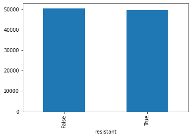

```python
DataDf.groupby('resistant').size().plot.bar()
plt.show()
```

Видим, что наша выборка сбалансирована

В следующем фрагменте кода достаем класс Tokenizer из библиотеке keras(Keras — открытая библиотека, написанная на языке Python и обеспечивающая взаимодействие с искусственными нейронными сетями. Она представляет собой надстройку над фреймворком TensorFlow).Этот класс позволяет векторизовать текстовый массив, например, в последовательнось целых чисел.

Подробное описание можно найти на github https://github.com/keras-team/keras-preprocessing/blob/1.1.2/keras_preprocessing/text.py#L141-L487

num_words - максимальное количество сохраняемых слов в зависимости от частоты слов

char_level - если True, каждый символ будет рассматриваться как токен

fit_on_texts обновляет внутренний словарь на основе списка текстов

texts_to_sequences transforms each text in texts to a sequence of integers.

```python
Datatok = DataDf.copy()
maxlen = 160 # обрезаем при достижении данной длины строки

max_words = 4 # всего 4 нуклеотида : A,T,G,C
max_features = max_words

tokenizer = Tokenizer(num_words=max_words, char_level=True)
tokenizer.fit_on_texts(list(Datatok['genes']))
sequences = tokenizer.texts_to_sequences(list(Datatok['genes']))
word_index = tokenizer.word_index
# делаем одного размера
Xpad = pad_sequences(sequences, maxlen=maxlen, padding='post', truncating='post', value=0)

print('Found %s unique tokens.' % len(word_index))
print('word_index', word_index)
```

```
Found 4 unique tokens.
word_index {'a': 1, 't': 2, 'c': 3, 'g': 4}
```

```python
labels = np.asarray(Datatok['resistant'])
print(Xpad.shape)
print(labels.shape)
```

```
(100000, 160)
(100000,)
```

```python
# посмотрим, что получается
rowNum = 37149
print(Datatok['genes'][rowNum])
print(sequences[rowNum])
print(Xpad[rowNum])
print(labels[rowNum])
```

```
ATGCACTACCGTATGATTCACTGGATGATGGAAATTGACTGCAATGGCTGCGCTAATAATACTTTGTCTCGTCGTTGGAATTACGACTTCTGGCACAAACACGTTGAACAGGTTAAATGCTACCGTCACAATATTCGTGACCAGACTTGA
[1, 2, 3, 1, 3, 2, 1, 3, 3, 2, 1, 2, 1, 2, 2, 3, 1, 3, 2, 1, 2, 1, 2, 1, 1, 1, 2, 2, 1, 3, 2, 3, 1, 1, 2, 3, 2, 3, 3, 2, 1, 1, 2, 1, 1, 2, 1, 3, 2, 2, 2, 2, 3, 2, 3, 2, 3, 2, 2, 1, 1, 2, 2, 1, 3, 1, 3, 2, 2, 3, 2, 3, 1, 3, 1, 1, 1, 3, 1, 3, 2, 2, 1, 1, 3, 1, 2, 2, 1, 1, 1, 2, 3, 2, 1, 3, 3, 2, 3, 1,…
[1 2 3 1 3 2 1 3 3 2 1 2 1 2 2 3 1 3 2 1 2 1 2 1 1 1 2 2 1 3 2 3 1 1 2 3 2
 3 3 2 1 1 2 1 1 2 1 3 2 2 2 2 3 2 3 2 3 2 2 1 1 2 2 1 3 1 3 2 2 3 2 3 1 3
 1 1 1 3 1 3 2 2 1 1 3 1 2 2 1 1 1 2 3 2 1 3 3 2 3 1 3 1 1 2 1 2 2 3 2 1 3
 3 1 1 3 2 2 1 0 0 0 0 0 0 0 0 0 0 0 0 0 0 0 0 0 0 0 0 0 0 0 0 0 0 0 0 0 0
 0 0 0 0 0 0 0 0 0 0 0 0]
True
```

Разобьем нашу выборку на тренировочную и тестовую.

```python
training_samples = int(Xpad.shape[0] * 0.9)

indices = np.arange(Xpad.shape[0])
# Перетасуем массив(Эта функция только перемешивает
# массив вдоль первой оси многомерного массива.
# Порядок подмассивов меняется, но их содержимое остается прежним).Что-то похожее на cross-validation
np.random.shuffle(indices)
Xpad = Xpad[indices]
labels = labels[indices]

x_train = Xpad[:training_samples]
y_train = labels[:training_samples]
x_test = Xpad[training_samples: ]
y_test = labels[training_samples: ]

print('x_train', x_train.shape)
print('y_train', y_train.shape)
print('x_test', x_test.shape)
print('y_test', y_test.shape)
```

```
x_train (90000, 160)
y_train (90000,)
x_test (10000, 160)
y_test (10000,)
```

## Построение модели

Keras — открытая библиотека, написанная на языке Python и обеспечивающая взаимодействие с искусственными нейронными сетями.

Модель Sequential подходит для простого стека слоев, где каждый слой имеет ровно один входной тензор и один выходной тензор

Embedding:Turns positive integers (indexes) into dense vectors of fixed size (4 так как 4 нуклеотида, 1 -размерность output)

Сonv1D : одномерный слой свертки (filter : Целое число, размерность выходного пространства (т.е. количество выходных фильтров в свертке). kernel_size : целое число или кортеж/список одного целого числа, указывающий длину окна одномерной свертки.)

MaxPooling1D : максимальная операция объединения для одномерного массива данных

Dropout : The Dropout layer randomly sets input units to 0 with a frequency of rate at each step during training time, which helps prevent overfitting. Inputs not set to 0 are scaled up by 1/(1 - rate) such that the sum over all inputs is unchanged.

Bidirectional : Двунаправленная оболочка для RNN . GRU: Закрытая рекуррентная единица.Используем для максимизации производительности

Про двунаправленность понравилось , как пишут https://proproprogs.ru/neural_network/bidirectional-rekurrentnye-neyronnye-seti

compile настраивает модель на обучение

```python
model = Sequential()
model.add(Embedding(4, 1, input_length=maxlen))
model.add(layers.Conv1D(128, 27, activation='relu'))
model.add(layers.MaxPooling1D(9))
model.add(layers.Dropout(0.5))
model.add(layers.Conv1D(128, 9, activation='relu'))
model.add(layers.Dropout(0.5))
model.add(layers.Bidirectional(layers.GRU(32, dropout=0.2, recurrent_dropout=0.2)))
model.add(Dense(1, activation='sigmoid'))
model.compile(optimizer='adam', loss='binary_crossentropy', metrics=['acc'])
model.summary()
```

```
Model: "sequential"
_________________________________________________________________
 Layer (type)                Output Shape              Param #
=================================================================
 embedding (Embedding)       (None, 160, 1)            4

 conv1d (Conv1D)             (None, 134, 128)          3584

 max_pooling1d (MaxPooling1D  (None, 14, 128)          0
 )

 dropout (Dropout)           (None, 14, 128)           0

 conv1d_1 (Conv1D)           (None, 6, 128)            147584

 dropout_1 (Dropout)         (None, 6, 128)            0

 bidirectional (Bidirectiona  (None, 64)               31104
 l)

 dense (Dense)               (None, 1)                 65

=================================================================
Total params: 182,341
Trainable params: 182,341
Non-trainable params: 0
_________________________________________________________________
```

```python
# Train / Validate model
# 10 иттераций
# batch_size : целое число или None. Количество выборок на обновление градиента.
# validation_split :  Доля обучающих данных, которые будут использоваться в качестве данных проверки
history = model.fit(x_train, y_train,
epochs = 10,
batch_size=32,
validation_split=0.2)
```

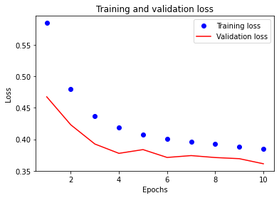

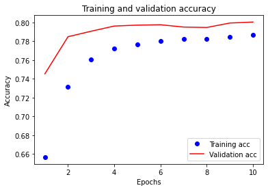

```python
plt.clf()
history_dict = history.history
loss_values = history_dict['loss']
val_loss_values = history_dict['val_loss']
epochs = range(1, (len(history_dict['loss']) + 1))
plt.plot(epochs, loss_values, 'bo', label='Training loss')
plt.plot(epochs, val_loss_values, 'r', label='Validation loss')
plt.title('Training and validation loss')
plt.xlabel('Epochs')
plt.ylabel('Loss')
plt.legend()
plt.show()

# VALIDATION ACCURACY curves

plt.clf()
acc_values = history_dict['acc']
val_acc_values = history_dict['val_acc']
epochs = range(1, (len(history_dict['acc']) + 1))
plt.plot(epochs, acc_values, 'bo', label='Training acc')
plt.plot(epochs, val_acc_values, 'r', label='Validation acc')
plt.title('Training and validation accuracy')
plt.xlabel('Epochs')
plt.ylabel('Accuracy')
plt.legend()
plt.show()
```

```python
# Final Predict on test

final_predictions = model.predict(x_test)
print(final_predictions)

# Modify the raw final_predictions - prediction probs  - into 0 and 1
# Cutoff point = 0.5

Preds = final_predictions.copy()
print(len(Preds))

Preds[ np.where( Preds >= 0.5 ) ] = 1
Preds[ np.where( Preds < 0.5 ) ] = 0
print(Preds)
```

```
[[0.9991114 ]
 [0.00134796]
 [0.99981725]
 ...
 [0.28091958]
 [0.87359464]
 [0.9997972 ]]
10000
[[1.]
 [0.]
 [1.]
 ...
 [0.]
 [1.]
 [1.]]
```

#### Посмотрим на качество нашей модели

[figure not shown]

```python
from IPython.display import HTML, Image
display(Image('метрика.jpg',width=200))
```

Для оценки качества работы алгоритма на каждом из классов по отдельности введем метрики precision (точность) и recall (полнота).

Precision можно интерпретировать как долю объектов, названных классификатором положительными и при этом действительно являющимися положительными, а recall показывает, какую долю объектов положительного класса из всех объектов положительного класса нашел алгоритм.

Precision и recall не зависят, в отличие от accuracy, от соотношения классов и потому применимы в условиях несбалансированных выборок.

Существует несколько различных способов объединить precision и recall в агрегированный критерий качества. F-мера (в общем случае $\ F_\beta$) — среднее гармоническое precision и recall :

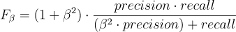

F-мера достигает максимума при полноте и точности, равными единице, и близка к нулю, если один из аргументов близок к нулю.

```python
# Confusion matrix
#TN - true / negative
conf_mx = confusion_matrix(y_test, Preds)

TN = conf_mx[0,0]
FP = conf_mx[0,1]
FN = conf_mx[1,0]
TP = conf_mx[1,1]

print ('TN: ', TN)
print ('FP: ', FP)
print ('FN: ', FN)
print ('TP: ', TP)

recall = TP/(TP+FN)
precision = TP/(TP+FP)

print (recall, precision)
```

```
TN:  4454
FP:  528
FN:  1528
TP:  3490
0.6954962136309286 0.8685913389746143
```

```python
def plot_confusion_matrix(cm,target_names,title='Confusion matrix',cmap=None,
                          normalize=False):
    import itertools
    accuracy = np.trace(cm) / float(np.sum(cm))
    misclass = 1 - accuracy

    if cmap is None:
        cmap = plt.get_cmap('Blues')

    plt.figure(figsize=(8, 6))
    plt.imshow(cm, interpolation='nearest', cmap=cmap)
    plt.title(title)
    plt.colorbar()

    if target_names is not None:
        tick_marks = np.arange(len(target_names))
        plt.xticks(tick_marks, target_names, rotation=45)
        plt.yticks(tick_marks, target_names)

    if normalize:
        cm = cm.astype('float') / cm.sum(axis=1)[:, np.newaxis]
    thresh = cm.max() / 1.5 if normalize else cm.max() / 2
    for i, j in itertools.product(range(cm.shape[0]), range(cm.shape[1])):
        if normalize:
            plt.text(j, i, "{:0.4f}".format(cm[i, j]),
                     horizontalalignment="center",
                     color="white" if cm[i, j] > thresh else "black")
        else:
            plt.text(j, i, "{:,}".format(cm[i, j]),
                     horizontalalignment="center",
                     color="white" if cm[i, j] > thresh else "black")


    plt.tight_layout()
    plt.ylabel('True label')
    plt.xlabel('Predicted label\naccuracy={:0.4f}; misclass={:0.4f}'.format(accuracy, misclass))
    plt.show()
```

[figure not shown]

```python
plot_confusion_matrix(conf_mx,
                      normalize    = False,
                      target_names = ['resistant', 'sensistive'],
                      title        = "Confusion Matrix ")
```

```python
print ('precision ',precision_score(y_test, Preds))
print ('recall ',recall_score(y_test, Preds) )
print ('accuracy ',accuracy_score(y_test, Preds))
print ('F1 score ',f1_score(y_test, Preds))
```

```
precision  0.8685913389746143
recall  0.6954962136309286
accuracy  0.7944
F1 score  0.7724656927844179
```

В нашей модели мы использовали бинарную классификацию. Так как у нас была сбалансированная выборка, поэтому порог в 0.5 оправдан. Но при несбалансированных выборках 0.5 не всегда правильно использовать, поэтому чтобы оценить модель в целом, не привязываясь к конкретному порогу, является AUC-ROC (или ROC AUC) — площадь (Area Under Curve) под кривой ошибок (Receiver Operating Characteristic curve ). Данная кривая представляет из себя линию от (0,0) до (1,1) в координатах True Positive Rate (TPR) и False Positive Rate (FPR): FPR показывает, какую долю из объектов negative класса алгоритм предсказал неверно. В идеальном случае, когда классификатор не делает ошибок (FPR = 0, TPR = 1) мы получим площадь под кривой, равную единице; в противном случае, когда классификатор случайно выдает вероятности классов, AUC-ROC будет стремиться к 0.5, так как классификатор будет выдавать одинаковое количество TP и FP.

```
AUC: 0.795
```

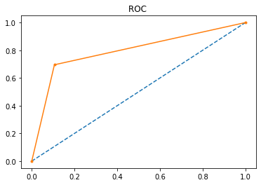

```python
auc = roc_auc_score(y_test, Preds)
print('AUC: %.3f' % auc)
# calculate roc curve
fpr, tpr, thresholds = roc_curve(y_test, Preds)
plt.plot([0, 1], [0, 1], linestyle='--')
# plot the roc curve for the model
plt.plot(fpr, tpr, marker='.')
plt.title('ROC ')
plt.show()
```

Precision и recall также используют для построения кривой и, аналогично AUC-ROC, находят площадь под ней.

```
f1=0.772 ap=0.757
```

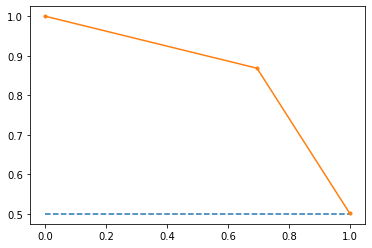

```python
# calculate precision-recall curve
precision, recall, thresholds = precision_recall_curve(y_test, Preds)
# calculate F1 score
f1 = f1_score(y_test, Preds)
# calculate average precision score
ap = average_precision_score(y_test, Preds)
print('f1=%.3f ap=%.3f' % (f1, ap))
plt.plot([0, 1], [0.5, 0.5], linestyle='--')
# plot the roc curve for the model
plt.plot(recall, precision, marker='.')
plt.show()
```

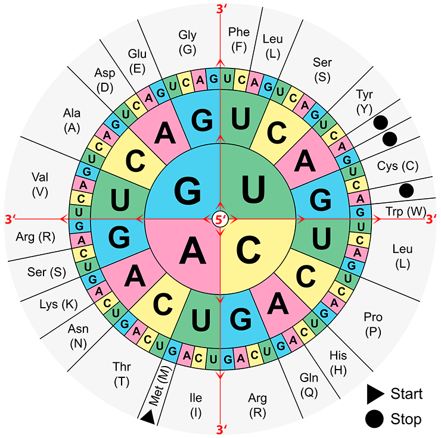

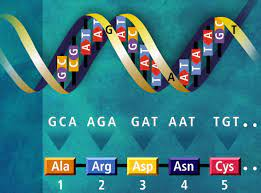

```python
display(Image('geneticcode.png',width=300))
display(Image('geneticcode2.jpg',width=300))
```

```python
# From nucleotides to codons ... w/o considering the start / stop codons as the data is synthetic and may not have these

DataCod = DataDf.copy()

Codons = list(DataCod['genes'])
print(len(Codons))

for n in range(len(Codons)):
    Codons[n] = list([Codons[n][i:i+3] for i in range(0, len(Codons[n]), 3)])

DataCod['codons'] = Codons
DataCod
```

```
100000
```

|  | resistant | genes | codons |
| --- | --- | --- | --- |
| 0 | False | ATGCACTACCGTATGATCCCCCTTCACTGGATGATGGAAATTGACT... | [ATG, CAC, TAC, CGT, ATG, ATC, CCC, CTT, CAC, ... |
| 1 | False | ATGCACTACCGTATGATTCACTGGATGATGGAAATTGACTGCAATG... | [ATG, CAC, TAC, CGT, ATG, ATT, CAC, TGG, ATG, ... |
| 2 | False | ATGCACTACCGTATGATTCACTGGATCGTGATGGAAATTGACTGCA... | [ATG, CAC, TAC, CGT, ATG, ATT, CAC, TGG, ATC, ... |
| 3 | False | ATGCACTACCGTATGATTCACTGGGTGATGGAAATTGACTGCAATG... | [ATG, CAC, TAC, CGT, ATG, ATT, CAC, TGG, GTG, ... |
| 4 | False | ATGCACGACCGTATCATTCACTGGATGATGGAAATTGACTGCAATG... | [ATG, CAC, GAC, CGT, ATC, ATT, CAC, TGG, ATG, ... |
| ... | ... | ... | ... |
| 99995 | False | ATGCACTACCGTATGATTCACTGGATGATGGAAACTCTCTTTGACT... | [ATG, CAC, TAC, CGT, ATG, ATT, CAC, TGG, ATG, ... |
| 99996 | False | ATGCACTACCGTATGATTCACTGGATGATGGAAATTGACTGCAATG... | [ATG, CAC, TAC, CGT, ATG, ATT, CAC, TGG, ATG, ... |
| 99997 | True | ATGCACTACCGTATGATTCACTGGATGATGGAAACTGCAATGGCTG... | [ATG, CAC, TAC, CGT, ATG, ATT, CAC, TGG, ATG, ... |
| 99998 | True | ATGCACTACCGTATGATTCACTGGATGATGGAAATTGACTTGCAAT... | [ATG, CAC, TAC, CGT, ATG, ATT, CAC, TGG, ATG, ... |
| 99999 | False | ATGCACTACCGTATGATTCACTGGATGATGGAAATTGACTGCAATG... | [ATG, CAC, TAC, CGT, ATG, ATT, CAC, TGG, ATG, ... |

100000 rows × 3 columns

```python
# Tokenize from codons to integers (sequences and then pad / truncate data)

maxlen = 53 # cut off after this number of codons in a list

max_words = 64 # considers only the top number of codons  in the dictionary (It finds 66 below because of 'a' and 'ga')
max_features = max_words

#tokenizer = Tokenizer(num_words=max_words, char_level=True)
tokenizer = Tokenizer(num_words=max_words)
tokenizer.fit_on_texts(list(DataCod['codons']))
sequences = tokenizer.texts_to_sequences(list(DataCod['codons']))
word_index = tokenizer.word_index
Xpad = pad_sequences(sequences, maxlen=maxlen, padding='post', truncating='post', value=0)

print('Found %s unique tokens.' % len(word_index))
print('word_index', word_index)
```

```
Found 66 unique tokens.
word_index {'cac': 1, 'cgt': 2, 'aat': 3, 'atg': 4, 'tac': 5, 'att': 6, 'tgg': 7, 'gac': 8, 'tgc': 9, 'act': 10, 'gtt': 11, 'gaa': 12, 'aaa': 13, 'cag': 14, 'tga': 15, 'ttg': 16, 'gct': 17, 'ttc': 18, 'tct': 19, 'ggc': 20, 'aca': 21, 'taa': 22, 'ctg': 23, 'ata': 24, 'caa': 25, 'ctt': 26, 'tcg': 27, …
```

```python
# Separate the label

labels = np.asarray(DataCod['resistant'])
print(Xpad.shape)
print(labels.shape)
```

```
(100000, 53)
(100000,)
```

```python
# Check a sample

rowNum = 37149
print(DataCod['genes'][rowNum])
print(DataCod['codons'][rowNum])
print(sequences[rowNum])
print(Xpad[rowNum])
print(labels[rowNum])
```

```
ATGCACTACCGTATGATTCACTGGATGATGGAAATTGACTGCAATGGCTGCGCTAATAATACTTTGTCTCGTCGTTGGAATTACGACTTCTGGCACAAACACGTTGAACAGGTTAAATGCTACCGTCACAATATTCGTGACCAGACTTGA
['ATG', 'CAC', 'TAC', 'CGT', 'ATG', 'ATT', 'CAC', 'TGG', 'ATG', 'ATG', 'GAA', 'ATT', 'GAC', 'TGC', 'AAT', 'GGC', 'TGC', 'GCT', 'AAT', 'AAT', 'ACT', 'TTG', 'TCT', 'CGT', 'CGT', 'TGG', 'AAT', 'TAC', 'GAC', 'TTC', 'TGG', 'CAC', 'AAA', 'CAC', 'GTT', 'GAA', 'CAG', 'GTT', 'AAA', 'TGC', 'TAC', 'CGT', 'CAC'…
[4, 1, 5, 2, 4, 6, 1, 7, 4, 4, 12, 6, 8, 9, 3, 20, 9, 17, 3, 3, 10, 16, 19, 2, 2, 7, 3, 5, 8, 18, 7, 1, 13, 1, 11, 12, 14, 11, 13, 9, 5, 2, 1, 3, 6, 2, 8, 14, 10, 15]
[ 4  1  5  2  4  6  1  7  4  4 12  6  8  9  3 20  9 17  3  3 10 16 19  2
  2  7  3  5  8 18  7  1 13  1 11 12 14 11 13  9  5  2  1  3  6  2  8 14
 10 15  0  0  0]
True
```

```python
# Create train & val and test datasets with inital shuffle (as the original dataset may be arranged)

training_samples = int(Xpad.shape[0] * 0.9)
# The validation is being taken by keras - below
# test = remaining

indices = np.arange(Xpad.shape[0])
np.random.shuffle(indices) # FOR TESTING PURPOSES comment it out - to keep indices as above

Xpad = Xpad[indices]
labels = labels[indices]

x_train = Xpad[:training_samples]
y_train = labels[:training_samples]
x_test = Xpad[training_samples: ]
y_test = labels[training_samples: ]

print('x_train', x_train.shape)
print('y_train', y_train.shape)
print('x_test', x_test.shape)
print('y_test', y_test.shape)
```

```
x_train (90000, 53)
y_train (90000,)
x_test (10000, 53)
y_test (10000,)
```

```python
# Model ... 64 CNN window 27 & Bidirectional GRU accuracy = 0.99

model = Sequential()
model.add(Embedding(64, 1, input_length=maxlen))
model.add(layers.Conv1D(128, 27, activation='relu'))
model.add(layers.MaxPooling1D(3))
model.add(layers.Dropout(0.5))
model.add(layers.Conv1D(128, 9, activation='relu'))
model.add(layers.Dropout(0.5))
model.add(layers.Bidirectional(layers.GRU(32, dropout=0.2, recurrent_dropout=0.2)))
model.add(Dense(1, activation='sigmoid'))
model.compile(optimizer='adam', loss='binary_crossentropy', metrics=['acc'])
model.summary()
```

```
Model: "sequential_1"
_________________________________________________________________
 Layer (type)                Output Shape              Param #
=================================================================
 embedding_1 (Embedding)     (None, 53, 1)             64

 conv1d_2 (Conv1D)           (None, 27, 128)           3584

 max_pooling1d_1 (MaxPooling  (None, 9, 128)           0
 1D)

 dropout_2 (Dropout)         (None, 9, 128)            0

 conv1d_3 (Conv1D)           (None, 1, 128)            147584

 dropout_3 (Dropout)         (None, 1, 128)            0

 bidirectional_1 (Bidirectio  (None, 64)               31104
 nal)

 dense_1 (Dense)             (None, 1)                 65

=================================================================
Total params: 182,401
Trainable params: 182,401
Non-trainable params: 0
_________________________________________________________________
```

```python
# Train / Validate model

history = model.fit(x_train, y_train,
epochs = 10,
batch_size=32,
validation_split=0.2)
```

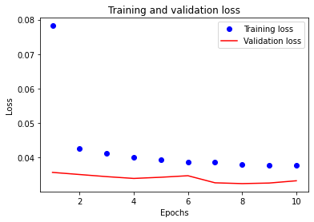

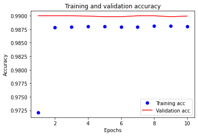

```python
# Learning curves

# VALIDATION LOSS curves

plt.clf()
history_dict = history.history
loss_values = history_dict['loss']
val_loss_values = history_dict['val_loss']
epochs = range(1, (len(history_dict['loss']) + 1))
plt.plot(epochs, loss_values, 'bo', label='Training loss')
plt.plot(epochs, val_loss_values, 'r', label='Validation loss')
plt.title('Training and validation loss')
plt.xlabel('Epochs')
plt.ylabel('Loss')
plt.legend()
plt.show()

# VALIDATION ACCURACY curves

plt.clf()
acc_values = history_dict['acc']
val_acc_values = history_dict['val_acc']
epochs = range(1, (len(history_dict['acc']) + 1))
plt.plot(epochs, acc_values, 'bo', label='Training acc')
plt.plot(epochs, val_acc_values, 'r', label='Validation acc')
plt.title('Training and validation accuracy')
plt.xlabel('Epochs')
plt.ylabel('Accuracy')
plt.legend()
plt.show()
```

```python
# Final Predict on test

final_predictions = model.predict(x_test)
print(final_predictions)

# Modify the raw final_predictions - prediction probs  - into 0 and 1
# Cutoff point = 0.5

Preds = final_predictions.copy()
print(len(Preds))

Preds[ np.where( Preds >= 0.5 ) ] = 1
Preds[ np.where( Preds < 0.5 ) ] = 0
print(Preds)
```

```
[[7.9753634e-05]
 [7.4293486e-05]
 [7.4833559e-05]
 ...
 [7.9084552e-05]
 [7.8186895e-05]
 [1.5037996e-01]]
10000
[[0.]
 [0.]
 [0.]
 ...
 [0.]
 [0.]
 [0.]]
```

```python
# Confusion matrix

conf_mx = confusion_matrix(y_test, Preds)

TN = conf_mx[0,0]
FP = conf_mx[0,1]
FN = conf_mx[1,0]
TP = conf_mx[1,1]

print ('TN: ', TN)
print ('FP: ', FP)
print ('FN: ', FN)
print ('TP: ', TP)

recall = TP/(TP+FN)
precision = TP/(TP+FP)

print (recall, precision)
```

```
TN:  5068
FP:  3
FN:  125
TP:  4804
0.974639886386691 0.9993759101310589
```

```python
# Function to visualize the confusion matrix

def plot_confusion_matrix(cm,target_names,title='Confusion matrix',cmap=None,
                          normalize=False):
    import itertools
    accuracy = np.trace(cm) / float(np.sum(cm))
    misclass = 1 - accuracy

    if cmap is None:
        cmap = plt.get_cmap('Blues')

    plt.figure(figsize=(8, 6))
    plt.imshow(cm, interpolation='nearest', cmap=cmap)
    plt.title(title)
    plt.colorbar()

    if target_names is not None:
        tick_marks = np.arange(len(target_names))
        plt.xticks(tick_marks, target_names, rotation=45)
        plt.yticks(tick_marks, target_names)

    if normalize:
        cm = cm.astype('float') / cm.sum(axis=1)[:, np.newaxis]

    thresh = cm.max() / 1.5 if normalize else cm.max() / 2
    for i, j in itertools.product(range(cm.shape[0]), range(cm.shape[1])):
        if normalize:
            plt.text(j, i, "{:0.4f}".format(cm[i, j]),
                     horizontalalignment="center",
                     color="white" if cm[i, j] > thresh else "black")
        else:
            plt.text(j, i, "{:,}".format(cm[i, j]),
                     horizontalalignment="center",
                     color="white" if cm[i, j] > thresh else "black")


    plt.tight_layout()
    plt.ylabel('True label')
    plt.xlabel('Predicted label\naccuracy={:0.4f}; misclass={:0.4f}'.format(accuracy, misclass))
    plt.show()
```

[figure not shown]

```python
plot_confusion_matrix(conf_mx,
                      normalize    = False,
                      target_names = ['resistant', 'sensistive'],
                      title        = "Confusion Matrix ")
```

```python
print ('precision ',precision_score(y_test, Preds))
print ('recall ',recall_score(y_test, Preds) )
print ('accuracy ',accuracy_score(y_test, Preds))
print ('F1 score ',f1_score(y_test, Preds))
```

```
precision  0.9993759101310589
recall  0.974639886386691
accuracy  0.9872
F1 score  0.9868529170090385
```

```
AUC: 0.987
```

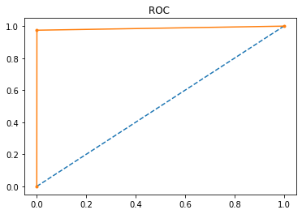

```python
# AUC/ROC curves should be used when there are roughly equal numbers of observations for each class
# Precision-Recall curves should be used when there is a moderate to large class imbalance

# calculate AUC
auc = roc_auc_score(y_test, Preds)
print('AUC: %.3f' % auc)
# calculate roc curve
fpr, tpr, thresholds = roc_curve(y_test, Preds)
plt.plot([0, 1], [0, 1], linestyle='--')
# plot the roc curve for the model
plt.plot(fpr, tpr, marker='.')
plt.title('ROC ')
plt.show()
```

```
f1=0.987 ap=0.987
```

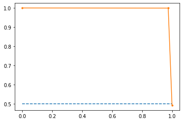

```python
# calculate precision-recall curve
precision, recall, thresholds = precision_recall_curve(y_test, Preds)
# calculate F1 score
f1 = f1_score(y_test, Preds)
# calculate average precision score
ap = average_precision_score(y_test, Preds)
print('f1=%.3f ap=%.3f' % (f1, ap))
plt.plot([0, 1], [0.5, 0.5], linestyle='--')
# plot the roc curve for the model
plt.plot(recall, precision, marker='.')
plt.show()
```

## Итоги

1) Наша модель имеет хорошее оценки качества НО это данные какого-то организма(бактерии), но непонятно какого. Антибиотик тоже неизвестен .

В защиту данной работы, это легко исправляется.

2)С точки зрения биологии, очевидно, что нужно разбирать последовательность не нуклеотидами, а кодонами( учитывая наличие старт/стоп кодонов )

3) Так как мы не гении, то брали код с kaggle немного дополняя его, но существует довольно много научных статей по этой теме.

Например, https://academic.oup.com/bioinformatics/article/38/2/325/6382301

В данной работе они оценили логистическую регрессию (LR), метод опорных векторов (SVM), случайный лес (RF) и сверточную нейронную сеть (CNN) для прогнозирования AMR для антибиотиков ципрофлоксацина, цефотаксима, цефтазидима и гентамицина. Как правило, RF и CNN работают лучше, чем LR и SVM с AUC до 0,96.

Существуют различные методы кодирования последовательностей ( Spänig and Heider, 2019 ), например, горячее кодирование или кодирование по метке. Горячее кодирование, также называемое разреженным кодированием, кодирует последовательность ДНК в бинарную матрицу, которая затем векторизуется и используется в качестве входных данных для моделей машинного обучения. Кодирование метки — еще один простой и понятный метод кодирования, при котором каждой метке присваивается уникальное целое число.